# Topic Modeling with Latent Dirichlet Allocation Demo

See `word_preprocess.ipynb` notebook for details about data and parameters used to clean, stem, lemmatize and tokenize the text data in preparation for LDA using Gensim. [[see 1]](#f1)

All global tuneable parameter settings can be adjusted manually on the `tuning_params.json` file. Settings used are saved here.

Click on `Click here to hide/show the current code cell` link underneath to display hidden code cells.

1- Methods to prepare data for topic modeling with the `sklearn` library are implemented with the `DimReducePlot` class in word_preprocess.py $\hookleftarrow$

### Load all libraries and modules, read files:

```python
%matplotlib inline

from matplotlib import pyplot as plt
from plotly.offline import init_notebook_mode
init_notebook_mode(connected=True) # may trigger a deprecation warning

import pandas as pd
from itertools import product
import json
from prettytable import PrettyTable
import time
start_time = time.time()
start_cpu = time.process_time()

from sklearn.feature_extraction.text import TfidfVectorizer
from nltk.stem import PorterStemmer, LancasterStemmer, SnowballStemmer
import gensim
import pyLDAvis
import pyLDAvis.gensim
pyLDAvis.enable_notebook()


# local modules
from helper.helper_funs import time_filename, save_folder_file, logged, RenderJSON
from methods.LDAprep import GensimPrep, GenMod, Diagnostics, ModelResults, TM_Results, HeatMapLDA
from helper.dk_ipython import toggled, one_cell_toggle

one_cell_toggle()
```

Click here to hide/show the current code cell

```python
with open('changeable_parameters/tuning_params.json') as json_file:
    tune_params = json.load(json_file)

cleaned_data_path = 'data/processed_data/cleaned_data.json'
with open(cleaned_data_path) as json__data:
    all_data = json.load(json__data)

one_cell_toggle()
```

Click here to hide/show the current code cell

### Fetch parameter data and data paths

```python
all_donnees = all_data['all_donnees']
processed_data = all_data['processed_data']
lda_table_path = all_data['generating_params']['lda_table_path']

paramsLDA = tune_params['set_kwargs']
kwargsLDA = paramsLDA['kwargsLDA']

one_cell_toggle()
```

Click here to hide/show the current code cell

### Viewing Hand Tunable LDA parameters as specified on tuning_params.json file

**Clear definitions of each manually-tuned LDA parameters are available in the file, under the key `help_kwargsLDA`.**

One can fetch individual definitions for reference, or all parameter details can be displayed as below:

```python
'''
Note: if more info is needed about the tunable parameters, type help_kwargs... with the parameter number
Example:
'''
x = PrettyTable()
x.title = "Hand tunable parameters - LDA"
fieldnames = ["Parameter", "Data Type", "Definition"]
x.field_names = fieldnames

for fname in fieldnames:
    x.align[fname] = "l"

[x.add_row([key, val[0], val[1]]) for key, val in paramsLDA['help_kwargsLDA'].items()]

print(x)

one_cell_toggle()
```

```
+-----------------------------------------------------------------------------------------------------------------------------------------------------+
|                                                            Hand tunable parameters - LDA                                                            |
+---------------------+--------------------+----------------------------------------------------------------------------------------------------------+
| Parameter           | Data Type          | Definition                                                                                               |
+---------------------+--------------------+----------------------------------------------------------------------------------------------------------+
| update_every        | int                | number of docs iterated through for each update - set to 0 for batch learning                            |
|                     |                    |                                                                                                          |
| passes              | int                | number of passes through corpus during training                                                          |
|                     |                    |                                                                                                          |
| iterations          | int                | max iterations through corpus when inferring topic distribution                                          |
|                     |                    |                                                                                                          |
| minimum_probability | float (0,1)        | min topic probability (discarded if under)                                                               |
|                     |                    |                                                                                                          |
| per_word_topics     | bool               | if True, also computes a list of topics, sorted in descending order of most likely topics for each word, |
|                     |                    | also computes lower bound on expected word count in topic (phi*len(feature))                             |
|                     |                    |                                                                                                          |
| minimum_phi_value   | float (0,1)        | min per word probability (discarding if under). `per_word_topics` must be set to True                    |
|                     |                    |                                                                                                          |
| alpha               | float (0,1) or str | topic prob. prior, can set each topic prior individually.                                                |
|                     |                    | str choices: ['auto': Empirical Bayes, 'asymmetric': 1/(topic_number)]                                   |
|                     |                    |                                                                                                          |
+---------------------+--------------------+----------------------------------------------------------------------------------------------------------+
```

Click here to hide/show the current code cell

### Set Local Parameters:

**Some parameters are specified locally.** These are the range of parameters to vary in the tuning to optimize the number of topics to declare. Here, we try all the parameter combinations for a number of topics from `start` to `max_num_topics`. For each number of topics tested, we ran all permutations of:

- priors on word probability, representing prior knowledge of the probability that word i is in topic j, with the sum of all topics for each word i equal to 1.
- decay, how much the weights (weights: word probability distribution over topics) of previous documents are 'forgotten' for each new document. Can be seen as priors on word probability (eta), for each document.

```python
to_log = True               # set to True to get log files
seed = all_data['generating_params']['seed']

tfidf = False         # using tfidf transformation before LDA?
eval_every = 5       # the smaller number, the more precise the convergence plot
# Log perplexity (think log-likelihood) is estimated every `eval_every` updates. Set down from 5 to 1 slows training by ~2x .

# tuning LDA for number of topics
max_num_topics = 14       # highest number
start = 4                 # lowest number
step = 1                  # granularity of topic number testing
etas = ['auto', 1e-3]           # prior on word probability ('auto' is Empirical Bayes, o/w scalar or vector)
decays = [0.5, 0.7]       # learning memory decay, between (0.5, 1.0]
```

```python
if to_log:
    full_path_log = logged(filename='LDA') # writes a log file, *necessary* to get convergence plot (perplexity or kl-div/elbo vs iter)
```

## Preparation Before Running LDA (Latent Dirichlet Allocation) Model.

**Additional cleaning**, creating the corpus and bag-of-words format, removing very common words. Saving the resulting corpus.

**The gensim LDA algorithm:**

- **Is streamed:** training documents may come in sequentially, no random access required.
- **Runs in constant memory w.r.t. the number of documents:** size of the training corpus does not affect memory footprint, can process corpora larger than RAM.
- **Is distributed:** makes use of a cluster of machines, if available, to speed up model estimation.

#### Making word -> number mappings, keeping track of count...

Building vocabulary and corpus as bag-of-word matrix representation:

```python
gp = GensimPrep(processed_data)

# see method/LDAprep.py for complete parameter definitions
lda_dict = gp.gensimDict(min_word_len=3,        # remove words smaller than min_word_len (should already be done in previous steps)
                         prop_docs=0.8,         # max proportion of docs a word can appear before being removed
                         save_dict=True,
                         save_dir='data/corpus_data')

unique_word_count = len(lda_dict)
bow_rep = gp.gensimBOW(lda_dict)

print('Number of words processed: {}\n '.format(lda_dict.num_pos))
print('Number of unique words remaining: {}\n\n'.format(unique_word_count))
print('*'*37 + '\n')

one_cell_toggle()
```

```
Removing words of less than 3 characters, and words present in at least 0.8% of documents

Removing gaps in indices caused by preprocessing...

Saving gensim dictionary to data/corpus_data/2019-2-25/Gensim_dict_Params_MWL3_PD0.8_18h35m2s.dict

Saving .mm matrix to data/corpus_data/2019-2-25/BOWmat18h35m2s.mm

Number of words processed: 40760

Number of unique words remaining: 1775
```

Click here to hide/show the current code cell

### Do Term Frequency - Inverse Document Frequency (TF-IDF) transformation if required

It is equivalent to the KL-Divergence between the distributions of the two components.

```python
if tfidf:
    bow_rep = gp.tfidf_trans(bow_rep, normalize=True)  # normalize to unit euclidean length

one_cell_toggle()
```

Click here to hide/show the current code cell

#### All the proper BOW matrices and vocabulary are saved in the folders specified above

### LDA hyperparameter search

Finding the ideal number of topics to set, and adjust other parameters as needed

```python
diag = Diagnostics(lda_dict,
                   bow_rep,
                   processed_data)

one_cell_toggle()
```

Click here to hide/show the current code cell

```python
model_list, res_df, res_dict = diag.compare_scores(max_num_topics = max_num_topics,
                                                   start = start,
                                                   step = step,
                                                   etas = etas,
                                                   decays = decays,
                                                   random_state = seed,
                                                   eval_every = eval_every,
                                                   **kwargsLDA)

# see complete parameter explanation on the methods module `methods.lda_prep.py`
```

```
Testing topics 4 to 13 for:


 auto eta and 0.5 decay...


 auto eta and 0.7 decay...


 0.001 eta and 0.5 decay...


 0.001 eta and 0.7 decay...
```

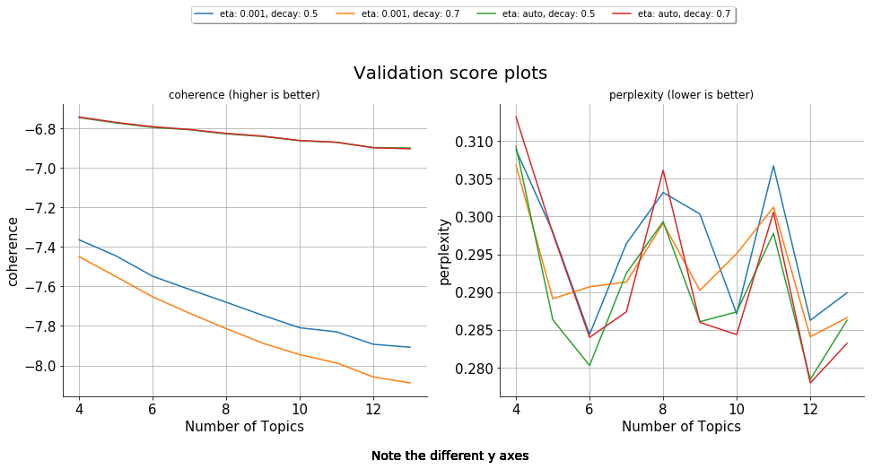

```python
diag.score_plot(tuning_df=res_df,
                save_plot=True,
                size=(16, 6))
```

#### Displaying the first few results from the tuning process:

```python
# diag.print_scores(res_dict) # can use print_scores method for different display
res_df.head(12)
```

|  | eta | decay | topic_num | coherence | perplexity |
| --- | --- | --- | --- | --- | --- |
| 0 | auto | 0.5 | 4 | -6.747143 | 0.309259 |
| 1 | auto | 0.5 | 5 | -6.773666 | 0.286334 |
| 2 | auto | 0.5 | 6 | -6.796538 | 0.280279 |
| 3 | auto | 0.5 | 7 | -6.808235 | 0.292488 |
| 4 | auto | 0.5 | 8 | -6.829494 | 0.299310 |
| 5 | auto | 0.5 | 9 | -6.842508 | 0.286075 |
| 6 | auto | 0.5 | 10 | -6.863735 | 0.287371 |
| 7 | auto | 0.5 | 11 | -6.872228 | 0.297781 |
| 8 | auto | 0.5 | 12 | -6.898547 | 0.278431 |
| 9 | auto | 0.5 | 13 | -6.900450 | 0.286265 |
| 10 | auto | 0.7 | 4 | -6.744152 | 0.313156 |
| 11 | auto | 0.7 | 5 | -6.771159 | 0.297766 |

### Alternatively, we can use tmtoolkit to test with different validation metrics

In many cases with the community art center dataset, the measures of distance are all over the place and not consistent with one another, which is worrisome.

The measures plotted here are:

- Pair-wise cosine distance method ([Cao et al 2009](https://www.sciencedirect.com/science/article/pii/S092523120800372X?via%3Dihub))
- Perplexity ([Arun et al 2010](https://link.springer.com/chapter/10.1007%2F978-3-642-13657-3_43))
- [Model Coherence](https://radimrehurek.com/gensim/models/coherencemodel.html)
- Alternative Model Coherence ([Mimno et al 2011](https://dl.acm.org/citation.cfm?id=2145462))

```
evaluating 10 topic models
```

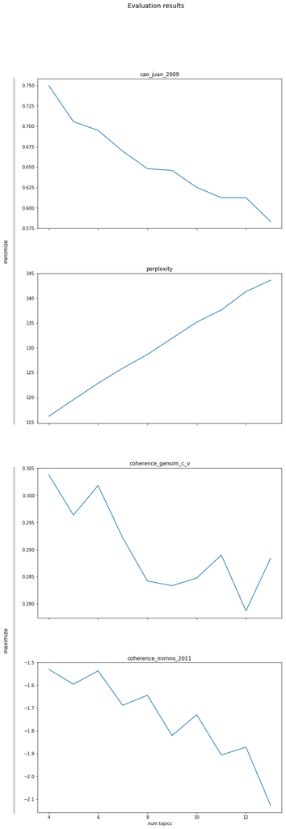

```python
# evaluate topic models with different parameters
const_params = dict(update_every=0, passes=10, random_state=seed,
                    iterations=1000, minimum_probability=0.01, minimum_phi_value=0.02)

ks = list(range(4, 14, 1))  # range of topic numbers
tops = {'num_topics': ks, 'alpha':[1/4.0], 'decay':[0.7]} # just a few values for demo

varying_params = [dict(zip(tops, v)) for v in product(*tops.values())]

tmtool_diag = diag.toolkit_cv_plot(varying_params, const_params, size=(10, 30))
```

### See results for optimal model:

```python
# get int index of best model in terms of coherence
max_idx = res_df[res_df['coherence'] == max(res_df['coherence'])].index.item()

n_clusters = res_df['topic_num'].iloc[max_idx]

# Select the model and print the topics
optimal_model = model_list[max_idx]

diag.print_model(optimal_model)

one_cell_toggle()
```

```
Topic: 1
Words:
0.019*"creativ" + 0.017*"cultur" + 0.013*"develop" + 0.012*"program" + 0.011*"project" + 0.011*"public" + 0.011*"social" + 0.011*"organ" + 0.010*"work" + 0.007*"perform"

Topic: 2
Words:
0.018*"program" + 0.016*"youth" + 0.013*"work" + 0.009*"provid" + 0.009*"cultur" + 0.008*"workshop" + 0.008*"theatr" + 0.008*"develop" + 0.008*"commun" + 0.008*"educ"

Topic: 3
Words:
0.023*"program" + 0.011*"work" + 0.010*"project" + 0.010*"support" + 0.008*"provid" + 0.008*"theatr" + 0.008*"educ" + 0.007*"mural" + 0.007*"member" + 0.007*"public"

Topic: 4
Words:
0.015*"creat" + 0.014*"work" + 0.013*"theatr" + 0.011*"space" + 0.011*"cultur" + 0.010*"public" + 0.010*"creativ" + 0.009*"perform" + 0.009*"social" + 0.008*"project"
```

Click here to hide/show the current code cell

## Results: diagnostic plots and summary tables

## Tables with Topic Modeling Summary

Tables showing the distribution of words within topics and distribution of topics within documents (1 document = all texts from 1 organization)

### Table 1: Show Most Important Topic in each Document.

Displays the topic number that contributes most to document (in terms of marginal probability). Very high probability (close to 1) indicates that the topics are apparently easily distinguished from one another.

Only a few documents are displayed below, but all organizations with non-empty text are gathered in this table.

```python
mod_res = ModelResults(optimal_model, bow_rep, all_donnees)

df_dominant_topic = mod_res.format_topics_sentences()

small_dom_topic = pd.concat([df_dominant_topic.Dominant_Topic.astype(int),
                             df_dominant_topic.Percent_Contribution,
                             df_dominant_topic.Important_Keywords,
                             df_dominant_topic.Mission], axis = 1)

small_dom_topic.columns = ['Dominant_Topic', 'Percent_Contribution', 'Important_Keywords', 'Mission']
one_cell_toggle()
```

```
Saving the table to: results/2019-2-25/dominant_topic_per_text_19h4m30s.csv
```

Click here to hide/show the current code cell

```python
small_dom_topic.head(10)
```

|  | Dominant_Topic | Percent_Contribution | Important_Keywords | Mission |
| --- | --- | --- | --- | --- |
| 0 | 2 | 0.8201 | program, youth, work, provid, cultur, workshop... | our goal is to have the space become self-sust... |
| 1 | 4 | 0.9984 | creat, work, theatr, space, cultur, public, cr... | white water gallery is a non-profit artist-run... |
| 2 | 3 | 0.9941 | program, work, project, support, provid, theat... | women sweetgrass film festival we provide opp... |
| 3 | 2 | 0.9992 | program, youth, work, provid, cultur, workshop... | in development to provide appropriate and aff... |
| 4 | 4 | 0.9926 | creat, work, theatr, space, cultur, public, cr... | to create original physical theatre to share o... |
| 5 | 2 | 0.9996 | program, youth, work, provid, cultur, workshop... | the woodland cultural centre is a first nation... |
| 6 | 3 | 0.9796 | program, work, project, support, provid, theat... | all disciplines artists with mental health and... |
| 7 | 4 | 0.9944 | creat, work, theatr, space, cultur, public, cr... | to provide an open and supportive environment ... |
| 8 | 2 | 0.7825 | program, youth, work, provid, cultur, workshop... | the mandate of the foundation is to build conn... |
| 9 | 1 | 0.7605 | creativ, cultur, develop, program, project, pu... | living arts is a multi-disciplinary cross-cul... |

### Table 2: Most Important Document/Text for each Topic

These are the documents that were most clealy classified into a given topic.

```python
tab_idx = mod_res.top_texts_per_topic(df_dominant_topic)
tab_idx.to_csv(lda_table_path)

tab = pd.concat([tab_idx.Dominant_Topic.astype(int),
                             tab_idx.Percent_Contribution,
                             tab_idx.Important_Keywords,
                             tab_idx.Mission], axis = 1)

tab.columns = ['Dominant_Topic', 'Percent_Contribution', 'Important_Keywords', 'Mission']
one_cell_toggle()
```

```
Saving the table to: results/2019-2-25/top_texts_per_topic19h4m30s.csv
```

Click here to hide/show the current code cell

```python
tab
```

|  | Dominant_Topic | Percent_Contribution | Important_Keywords | Mission |
| --- | --- | --- | --- | --- |
| 0 | 1 | 0.9998 | creativ, cultur, develop, program, project, pu... | through august the community of jackson hole w... |
| 1 | 2 | 0.9999 | program, youth, work, provid, cultur, workshop... | allied arts is oklahomas only united arts fund... |
| 2 | 3 | 0.9996 | program, work, project, support, provid, theat... | theater company outreach has launched heroes s... |
| 3 | 4 | 0.9994 | creat, work, theatr, space, cultur, public, cr... | artistic mission and profile of the organizati... |

```python
# Show most relevant text for each topic

mod_res.print_top_sentences_for_topic(tab, topic_num=2)
```

```
Top entry for topic 3 (with 0.9996 contribution):
theater company outreach has launched heroes stories programming for war veterans to honor and empower our country s brave service members in partnership with new directions at its local veterans affairs office the program gives vets a safe outlet to voice their own heroic experiences and stories st…
```

```python
mod_res.per_word_contrib(num_words=5)
```

```
Topic: 1
	Word,	 Weight
	----     -----------

	"creativ":  0.019
	"cultur":  0.017
	"develop":  0.013
	"program":  0.012
	"project":  0.011
	--------------------

Topic: 2
	Word,	 Weight
	----     -----------

	"program":  0.018
	"youth":  0.016
	"work":  0.013
	"provid":  0.009
	"cultur":  0.009
	--------------------

Topic: 3
	Word,	 Weight
	----     -----------

	"program":  0.023
	"work":  0.011
	"project":  0.01
	"support":  0.01
	"provid":  0.008
	--------------------

Topic: 4
	Word,	 Weight
	----     -----------

	"creat":  0.015
	"work":  0.014
	"theatr":  0.013
	"space":  0.011
	"cultur":  0.011
	--------------------
```

### Table 3: How documents are distributed between topics

```python
mod_res.topic_distribution(df_dominant_topic, tab)
```

```
Saving the table to: results/2019-2-25/doc_distribution_in_topics19h4m31s.csv
```

|  | Dominant_Topic | Important_Keywords | Num_Documents | Perc_Documents |
| --- | --- | --- | --- | --- |
| 0 | 1 | creativ, cultur, develop, program, project, pu... | 153 | 0.19590 |
| 1 | 2 | program, youth, work, provid, cultur, workshop... | 367 | 0.46991 |
| 2 | 3 | program, work, project, support, provid, theat... | 72 | 0.09219 |
| 3 | 4 | creat, work, theatr, space, cultur, public, cr... | 189 | 0.24200 |

## Relevance and Distinctiveness

The results above, using a naive coherence measure for tuning, are underwhelming.

Here are some results using:

### Relevance score [Sievert and Shirley 2014](http://www.aclweb.org/anthology/W14-3110)

Used to determine the "importance" for words of the corpus for a given topic (not the whole corpus). Very frequent but unspecific words will be ranked lower than more specific but less frequent words. Weight parameter $\lambda$ defines the influence of a word's lift within a topic (the ratio of a term's probability within a topic to its marginal probability across the whole corpus). Setting $\lambda=1$ means no influence of the lift quantity and results in the same ranking as given by the topic-word distribution. $\lambda=0$ only uses lift for the ranking.

Please note that the $\lambda$ parameter of the relevance score functions in tmtoolkit can be set with lambda_=.... The underscore is important to avoid making an anonymous function.

Calculate the relevance score from the model using a specific value of $\lambda$. The result is a $N \times M$ matrix with $N$ being the number of topics and $M$ being the size of the vocabulary.

### Also using:

### Distinctiveness and saliency [Chuang et al 2012](https://dl.acm.org/citation.cfm?id=2254572)

Used to reflect some kind of "importance" of word for the whole corpus. Very often occurring but very general words will be ranked lower, whereas more specific but less often occuring words will be ranked higher.

Calculation of the word distinctiveness score for the whole vocabulary in the corpus.

**Measure descriptions can be found [here](https://github.com/WZBSocialScienceCenter/tmtoolkit/blob/master/examples/word_and_topic_scores.ipynb)**

#### View `LDAprep.py` file to see more diagnostic measures and plots

```python
top_n = 30 # number of keywords to display

tm_res = TM_Results(optimal_model,
                    bow_rep,
                    lda_dict,
                    n_clusters)

one_cell_toggle()
```

```
- 4 topics learnt from 781 documents with vocabulary size of 1775 unique words.


Marginal topic distribution Pr(Topic):
[0.19070579 0.5227141  0.09265965 0.19392046]
```

Click here to hide/show the current code cell

### Samples of words strongly related to each category/topic

Shows **most** relevant and **least** relavant words for each category

```python
most_distinct, least_distinct = tm_res.tm_distinct(top_n = top_n)

most_relevant = []
least_relevant = []

for topic in range(n_clusters):
    most_rel, least_rel = tm_res.tm_relevant(topic_num = topic, top_n = top_n)
    most_relevant.append(most_rel)
    least_relevant.append(least_rel)
    print('\n{} most relevant words in topic {}:\n{}\n'.format(top_n, topic + 1, most_rel))
    print('\n{}] least relevant words in topic {}:\n{}\n'.format(top_n, topic + 1, least_rel))
    print('*'*18)

one_cell_toggle()
```

```
Computing 30 least and most distinct words.


30 most relevant words in topic 1:
['creativ' 'cultur' 'develop' 'public' 'social' 'organ' 'project'
 'program' 'local' 'work' 'plan' 'collabor' 'event' 'perform' 'circu'
 'econom' 'citi' 'commiss' 'engag' 'network' 'innov' 'promot' 'area'
 'place' 'new' 'social_chang' 'student' 'practic' 'commun' 'sector']


30] least relevant words in topic 1:
['class' 'employ' 'queer' 'main' 'home' 'love' 'respect' 'homeless' 'fun'
 'graffiti' 'imag' 'violenc' 'instrument' 'target' 'nativ' 'gather' 'cost'
 'ensembl' 'suppli' 'black' 'write' 'right' 'session' 'filmmak' 'musician'
 'desir' 'self-esteem' 'high_qualiti' 'drop-in' 'larger']

******************

30 most relevant words in topic 2:
['youth' 'program' 'work' 'provid' 'workshop' 'music' 'commun' 'theatr'
 'cultur' 'educ' 'support' 'develop' 'peopl' 'includ' 'project' 'creat'
 'danc' 'particip' 'offer' 'group' 'opportun' 'perform' 'organ' 'creativ'
 'visual' 'centr' 'tradit' 'school' 'profession' 'film']


30] least relevant words in topic 2:
['discours' 'commerci' 'situat' 'multi-facet' 'pave' 'recoveri' 'spark'
 'face_barrier' 'cirqu' 'year_ago' 'anti-oppress' 'stress' 'emerg_leader'
 'concentr' 'forum_theatr' 'sourc' 'secondari' 'justic' 'solidar' 'devot'
 'month' 'curios' 'eco' 'port' 'factori' 'clay' 'squamish' 'suitabl'
 'racial' 'minor']

******************

30 most relevant words in topic 3:
['program' 'mural' 'patient' 'support' 'studio' 'member' 'printmak'
 'graffiti' 'school' 'project' 'associ' 'health' 'veteran' 'work' 'provid'
 'challeng' 'engag' 'public' 'educ' 'galleri' 'help' 'profession' 'ticket'
 'theatr' 'collect' 'artwork' 'disabl' 'woman' 'contact' 'local']

```

[output cut: 8 more lines]

```

30 most relevant words in topic 4:
['creat' 'space' 'theatr' 'work' 'public' 'dialogu' 'cultur' 'creativ'
 'social' 'issu' 'perform' 'practic' 'transform' 'make' 'build' 'world'
 'share' 'chang' 'theater' 'activ' 'promot' 'project' 'peopl' 'visual'
 'medium' 'engag' 'commun' 'live' 'exhibit' 'challeng']


30] least relevant words in topic 4:
['fund' 'center' 'staff' 'artwork' 'addit' 'hous' 'career' 'bring_togeth'
 'avail' 'care' 'offic' 'come' 'director' 'profession_develop' 'techniqu'
 'travel' 'everi' 'made' 'graffiti' 'recogn' 'venu' 'session' 'lgbt'
 'board' 'award' 'sever' 'plan' 'filmmak' 'great' 'island']

******************
```

Click here to hide/show the current code cell

### Most 'distinctive' words overall:

```python
most_distinct  # showing most 'distinct' words according to measure defined above:
```

```
array(['patient', 'veteran', 'treatment', 'printmak', 'graffiti', 'mural',
       'face_barrier', 'post', 'militari', 'rehabilit', 'ticket', 'minor',
       'reintegr', 'trauma', 'wall', 'healthcar', 'contact', 'commerci',
       'seat', 'rental', 'depart', 'blog', 'war', 'sourc', 'blind',
       'exampl', 'stress', 'ive', 'ill', 'lack'], dtype='<U25')
```

### Heat map fo LDA

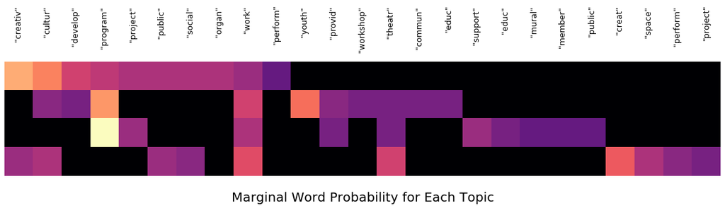

Click here to hide/show the current code cell

```python
plt.rcParams['figure.figsize'] = [20, 15]

HeatMapLDA(optimal_model, n_clusters).heat_plot(num_word_displayed=20, is_horizontal=True)
one_cell_toggle()
```

### Topic visualization using pyLDAvis

Can display t-sne, PCA or MDS dimension reduction schemes

```python
# possible dimension reduction schemes for visualization: 'pcoa', 'mmds' or 'tsne'
diag.LDAvis(optimal_model, is_notebook=True, mds='tsne')
```

```
Rendering visualization...
```

[interactive chart not shown]

```python
end_time = time.time()
end_cpu = time.process_time()

time_taken = end_time - start_time
cpu_time = end_cpu - start_cpu
print('Time elapsed to run code: {}\nCPU time elapsed: {}'.format(round(time_taken, 3), round(cpu_time, 3)))
```

```
Time elapsed to run code: 1875.634
CPU time elapsed: 1547.516
```